# Reproducible Research: Peer Assessment 1

| ## Loading and preprocessing the data |
| --- |
| First of all, we need to unzip and read the input file with R code: |

`r unzip("activity.zip")`

`## Warning in unzip("activity.zip"): error 1 in extracting from zip file`

`r activityRecords<-read.csv("activity.csv")`

## What is mean total number of steps taken per day?

The total number of steps taken per dat is calculate:

`r steps.date<-aggregate(steps~date,data=activityRecords,FUN=sum)`

`r barplot(steps.date$steps, names.arg=steps.date$date, xlab="Days", ylab="NumOfsteps")`

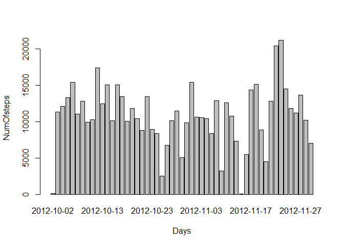

Mean and median is calculated by following code:

`r mean(steps.date$steps)`

`## [1] 10766.19`

`r median(steps.date$steps)`

`## [1] 10765`

Max step numbers are calculated:

`r steps.interval$interval[which.max(steps.interval$steps)]`

`## [1] 835`

## Imputing missing values

Total number of missing values are calculated:

`r sum(is.na(activityRecords$steps))`

`## [1] 2304`

Devise a strategy: Actualy, if there is no data, I prefer to replace with means.

Missing values are replaced:

`r cleanDataSet <- merge(activityRecords, steps.interval, by="interval", suffixes=c("",".y")) nas <- is.na(cleanDataSet$steps) cleanDataSet$steps[nas] <- cleanDataSet$steps.y[nas] cleanDataSet <- cleanDataSet[,c(1:3)]` You can find the related plots:

`r steps.date<-aggregate(steps~date,data=cleanDataSet,FUN=sum) barplot(steps.date$steps,names.arg=steps.date$date,xlab="Days",ylab="NumOfsteps")`

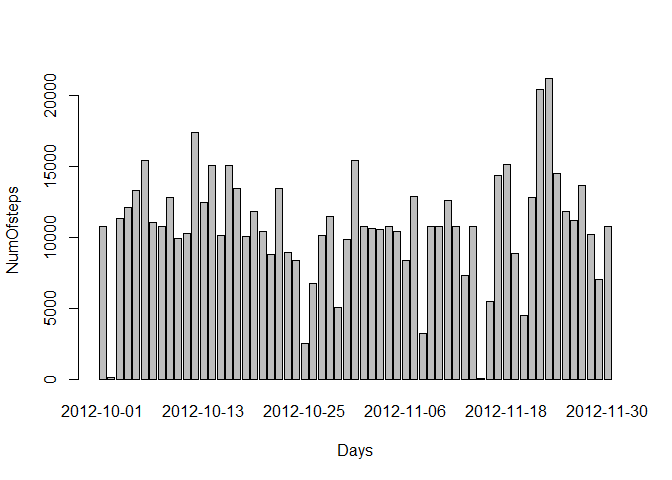

`r mean(steps.date$steps)`

`## [1] 10766.19`

`r median(steps.date$steps)`

`## [1] 10766.19`

## Are there differences in activity patterns between weekdays and weekends?

Day type variable is created:

`r dType <- function(date) { if (weekdays(as.Date(date)) %in% c("Saturday", "Sunday")) { "Weekend" } else { "Week Day" } } cleanDataSet$dType <- as.factor(sapply(cleanDataSet$date, dType))`

Plots are produced:

`r par(mfrow=c(2,1)) for (type in c("Weekend", "Week Day")) { steps.type <- aggregate(steps ~ interval,data=cleanDataSet,subset=cleanDataSet$dType==type,FUN=mean) plot(steps.type, type="l", main=type) }`

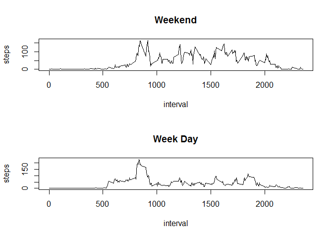